# LADS MINI-HACKATHON: Exploratory Data Analysis for News Classification

Group 3

2015.11.19

In analyzing the given news materials for future implementation of news classification, we have inspected the materials in three steps.

# Major stages of exploratory data analysis

## First stage: linguistic observation

At the preliminary stage, we inspected the materials mannualy and tried to characterize each topic/category (hencetoforth referred to as “category”). We also considered what might make the potential “noises” that could interfere further data analysis but nevertheless existed in the given data set. Characteristics observed each category are presented as follows:

- **Category #4** contains more Taiwan-specifc names for administrative divisions and/or places.
- **Category #5** contains more Mainland China-specific names for administrative divisions and/or for places.
- **Category #6** contains more foreign names (usually, if not always, presented in English without spaces), and occasional full-width dots that are meant to hyphenate foreign names.
- **Category #7** contains more colons (:) preceded and followed by one- or two-digits numbers, which are rather significant and should not be treated as merely noise.
- **Category 08** contains more specific names of educational institutions, organizations or relevant names. It also has more phone numbers and URLs.
- **Category 09** contains comparatively more numberic data and phone numbers.
- **Category 10** contains miscelleneous data that don’t usually go to any of the rest of the categories. Also relatively shorter in length.

The first three categories are not explicilty described because they don’t exhibit distinct chateritistics in terms of their diction and use of punctuation, and are further analyzed in the following two stages.

## Second stage: Building frequency lists for each category

Having familiarized ourselves with the materials, we then managed to find out “keywords” for each category. Keywords are of the following characteristics: (1) they are meaningful linguistics sequences; (2) they occur the most frequently in their respective categories and are semantically relevant to them.

## Third stage: Creating POS tags

The third stage has to do with the relation between lexical classes and categorical characteristics. Based on the segmented words, we created POS tags, where applicable, and then synthesized the significance of the generated tags.

Relevant code and graphs are as follows.

# Code and graphs

## Code

```
library(jiebaR)
Strain<-read.csv(file = "/Users/kentchang/Dropbox/104-1/07 Linguistics Analysis and Data Science/mini-hackathon/data/train.csv", header=F)
##Category 1
set1<-subset(Strain, V2==1)
txt1<-paste(set1$V3)
word_vector=worker(type='tag', stop_word = STOPPATH)<=txt1
f<-readLines('/Users/kentchang/Dropbox/104-1/07 Linguistics Analysis and Data Science/mini-hackathon/stopwords.txt')
stopwords<-c(NULL)
for(i in 1:length(f))
  {
  stopwords[i]<-f[i]
}
word_vector<-filter_segment(word_vector,stopwords)
tag_vector=names(word_vector)

## 100 most frequent words
wordst1<-sort(table(word_vector),decreasing=T)
head(wordst1, 100)
## frequency table of POS tags
t1<-sort(table(tag_vector),decreasing=T)
##get all nouns and the frequency table thereof
nountag_vector=grep(pattern='n',x=tag_vector,value=T)
sorted_tags=sort(table(nountag_vector),decreasing=T)
barplot(sorted_tags)
##the frequency table of the noun list
index_vector=grep(pattern='n',x=tag_vector,value=F)
sorted_nouns=sort(table(word_vector[index_vector]),decreasing=T)
barplot(sorted_nouns)



## Category 2
set2<-subset(Strain, V2==2)
txt2<-paste(set2$V3)
word_vector2=worker(type='tag', stop_word = STOPPATH)<=txt2
f<-readLines('/Users/kentchang/Dropbox/104-1/07 Linguistics Analysis and Data Science/mini-hackathon/stopwords.txt')
stopwords<-c(NULL)
for(i in 1:length(f))
  {
  stopwords[i]<-f[i]
```

[output cut: 218 more lines]

```
tag_vector10=names(word_vector10)
## 20 most frequent words
wordst10<-sort(table(word_vector10),decreasing=T)
head(wordst10, 20)
## frequency table of POS tags
t10<-sort(table(tag_vector10),decreasing=T)
## get all nouns and the frequency table thereof
nountag_vector10=grep(pattern='n',x=tag_vector10,value=T)
sorted_tags10=sort(table(nountag_vector10),decreasing=T)
par(family='PMingLiU')
barplot(sorted_tags10)
##the frequency table of the noun list
index_vector10=grep(pattern='n',x=tag_vector10,value=F)
sorted_nouns10=sort(table(word_vector10[index_vector10]),decreasing=T)
barplot(sorted_nouns10)
```

## Graphs

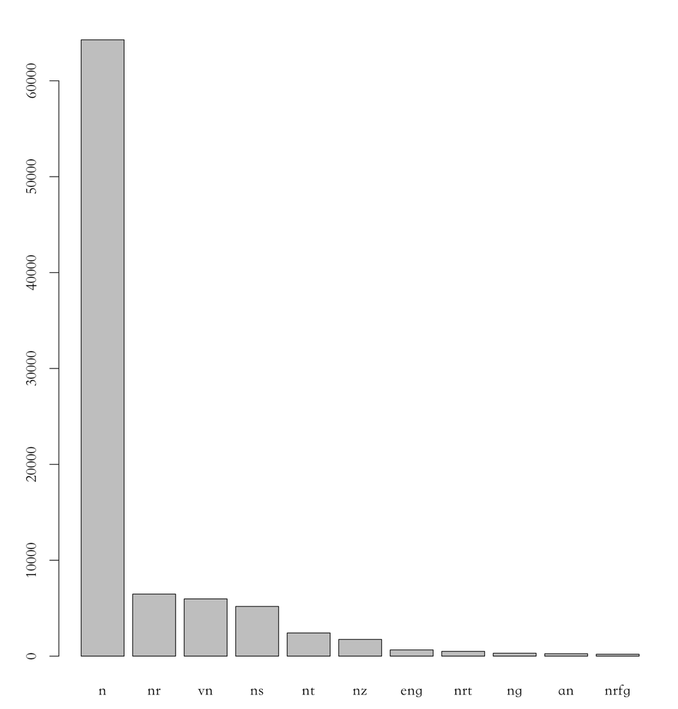

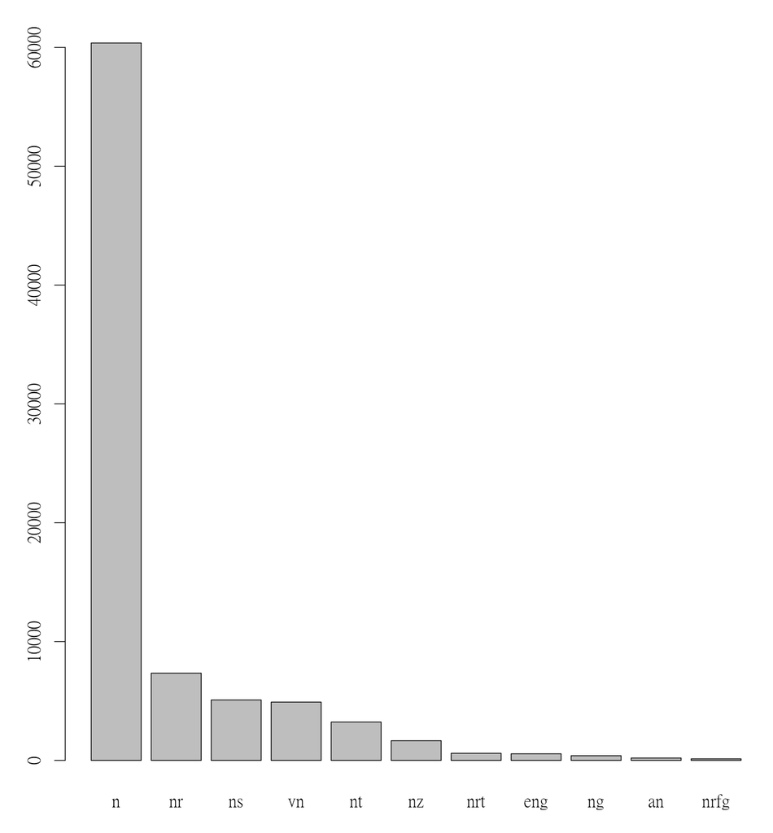

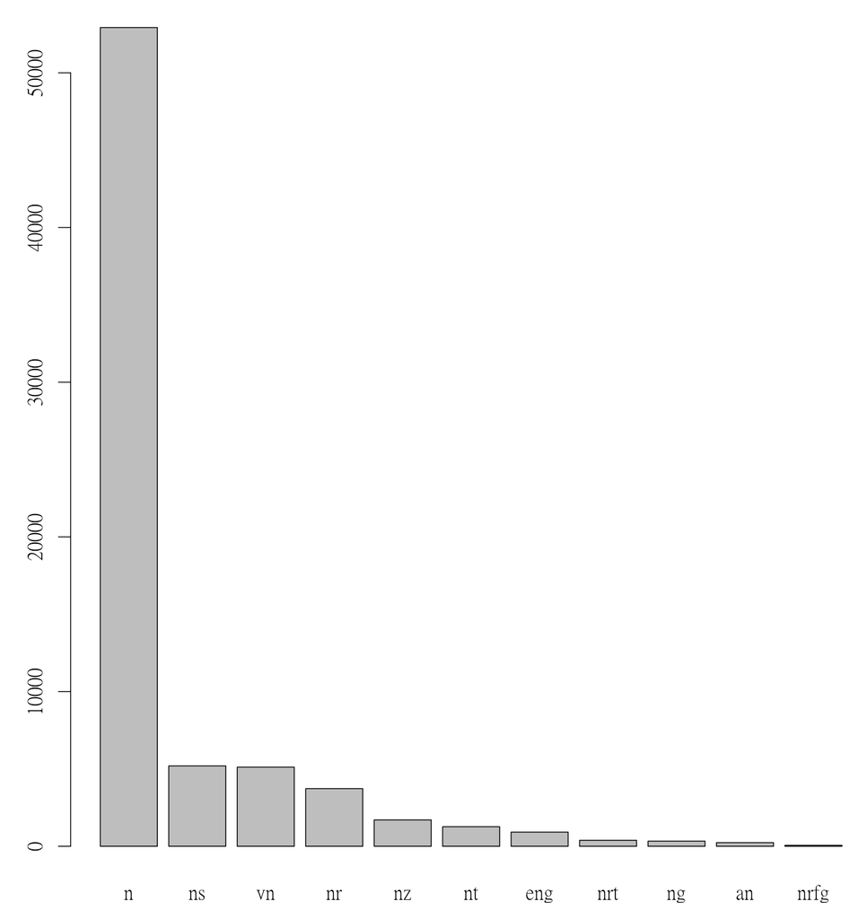

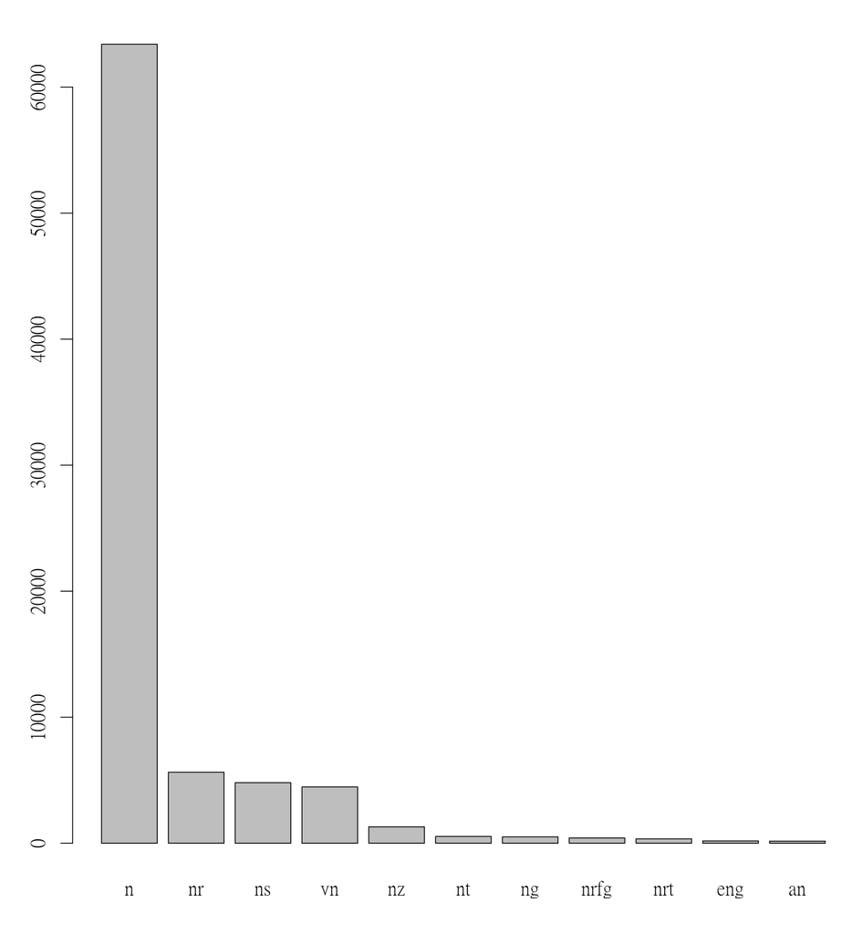

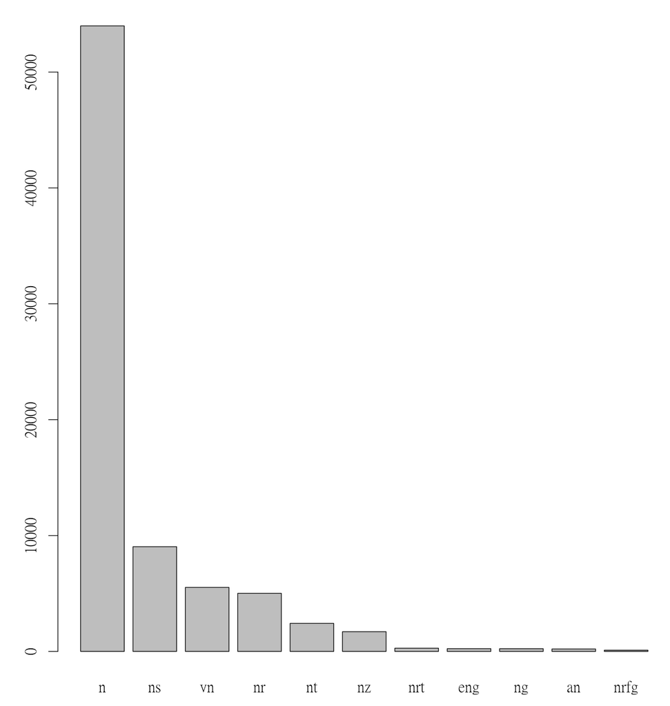

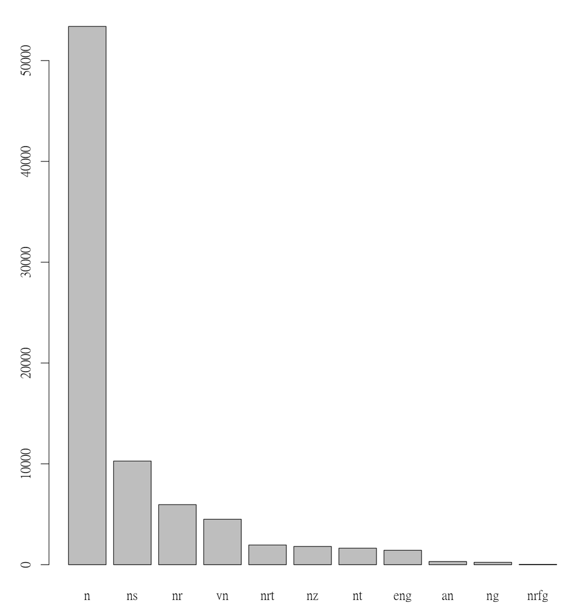

[figure not shown]

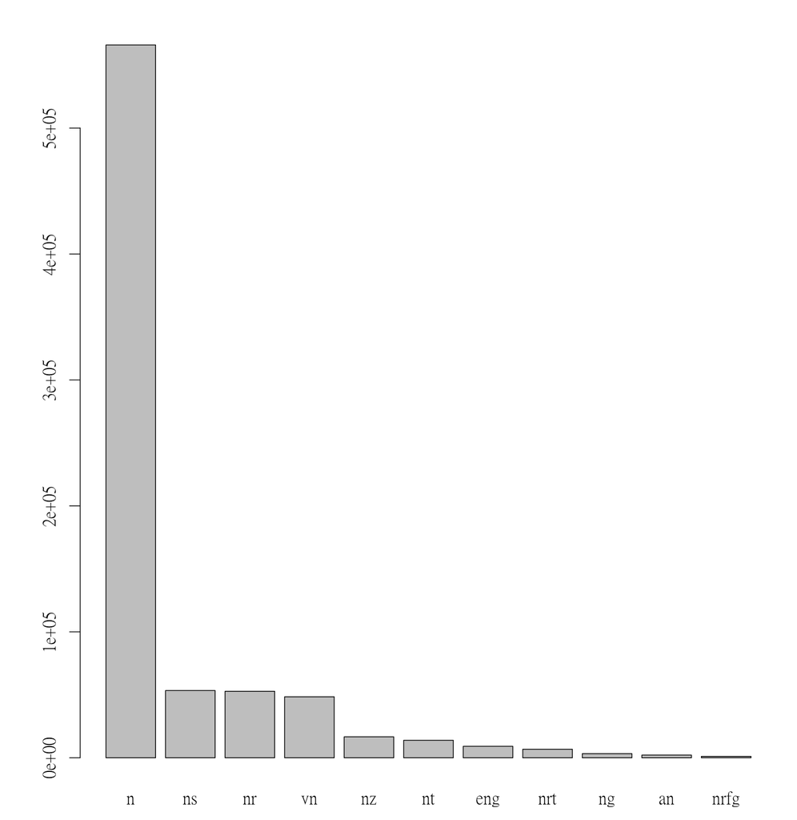

[figure not shown]

[figure not shown]

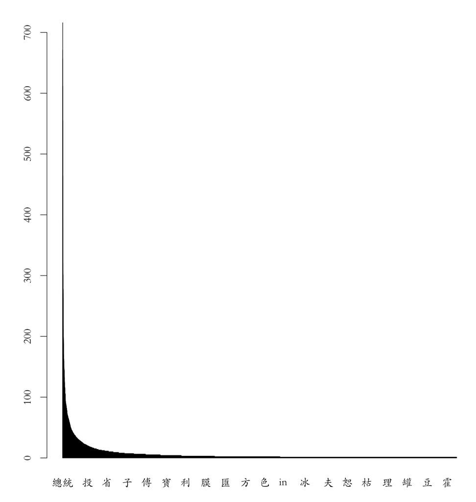

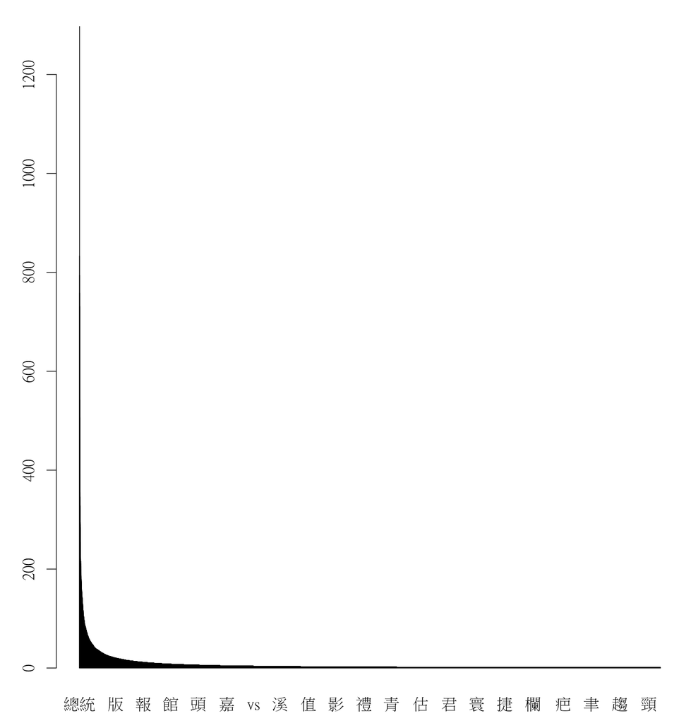

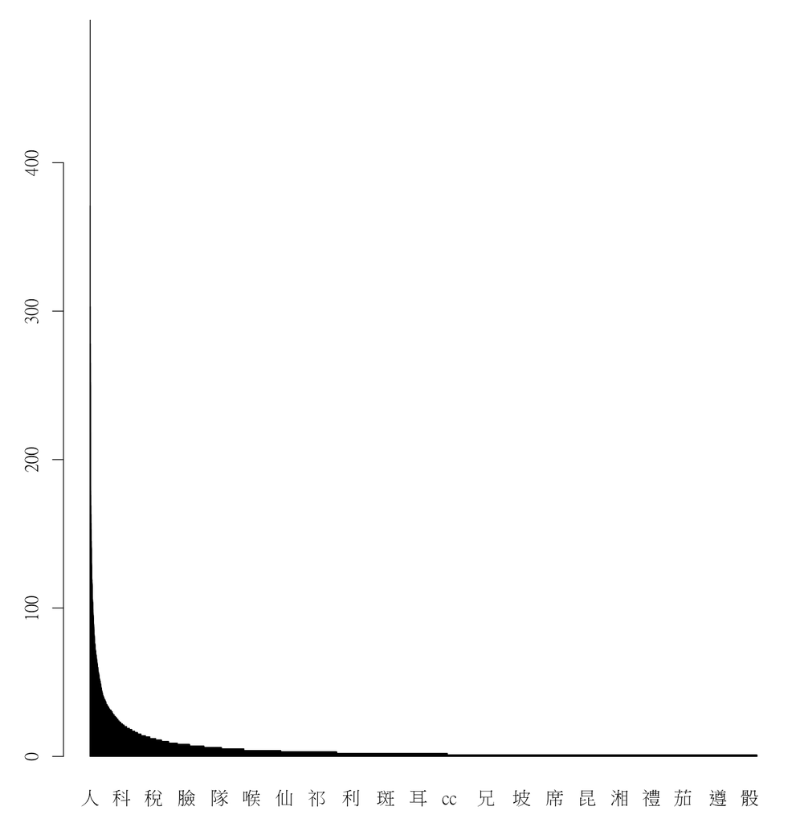

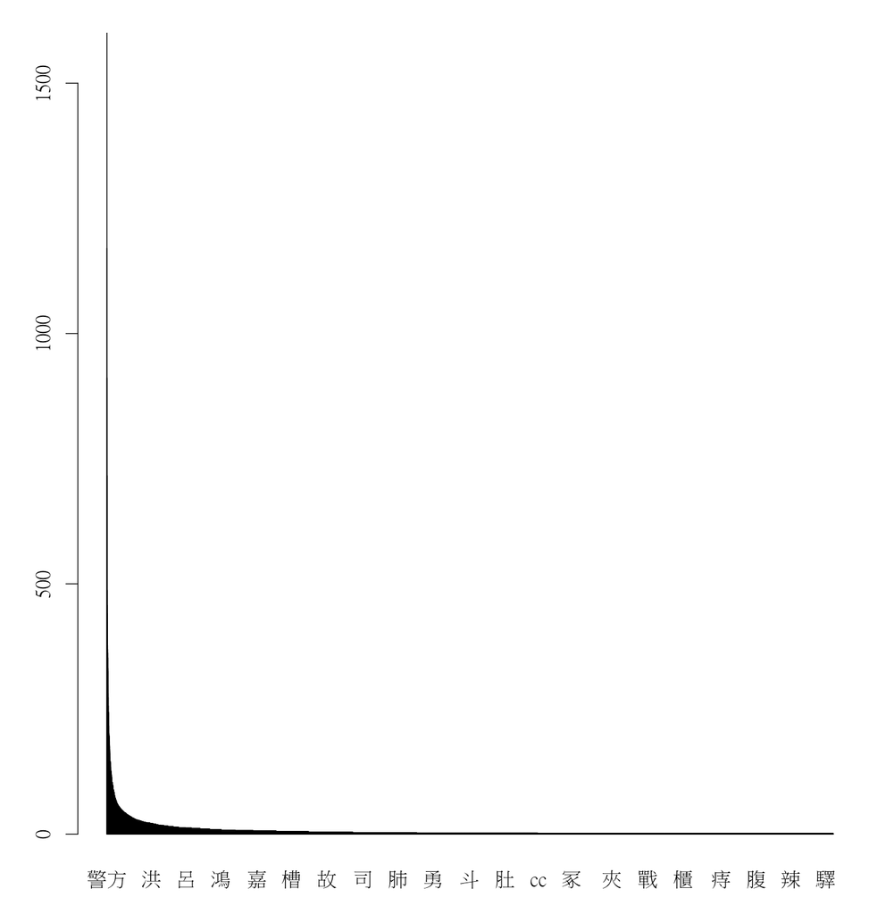

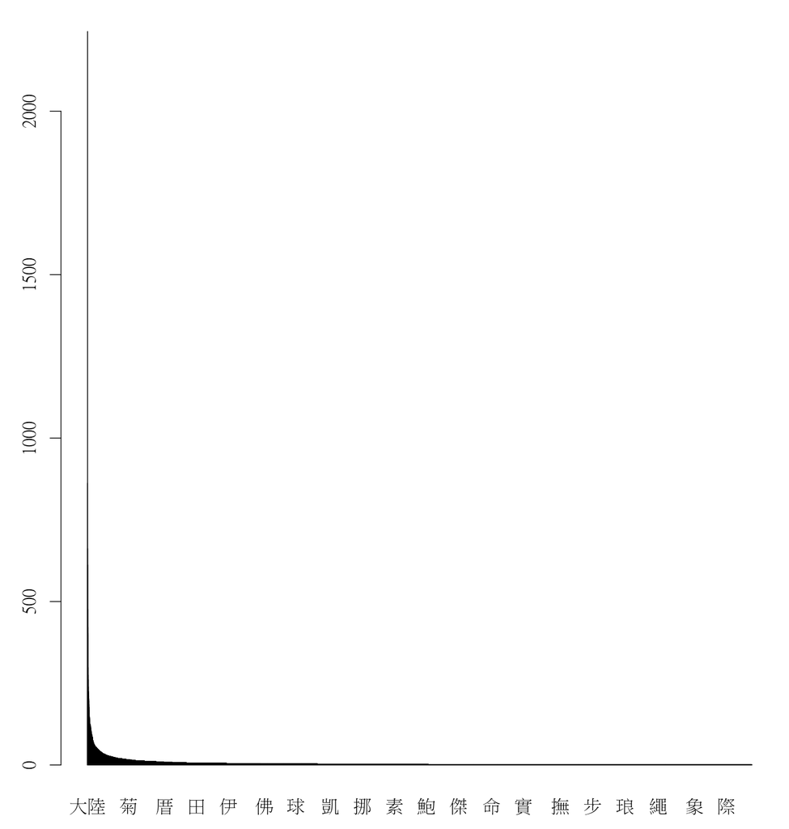

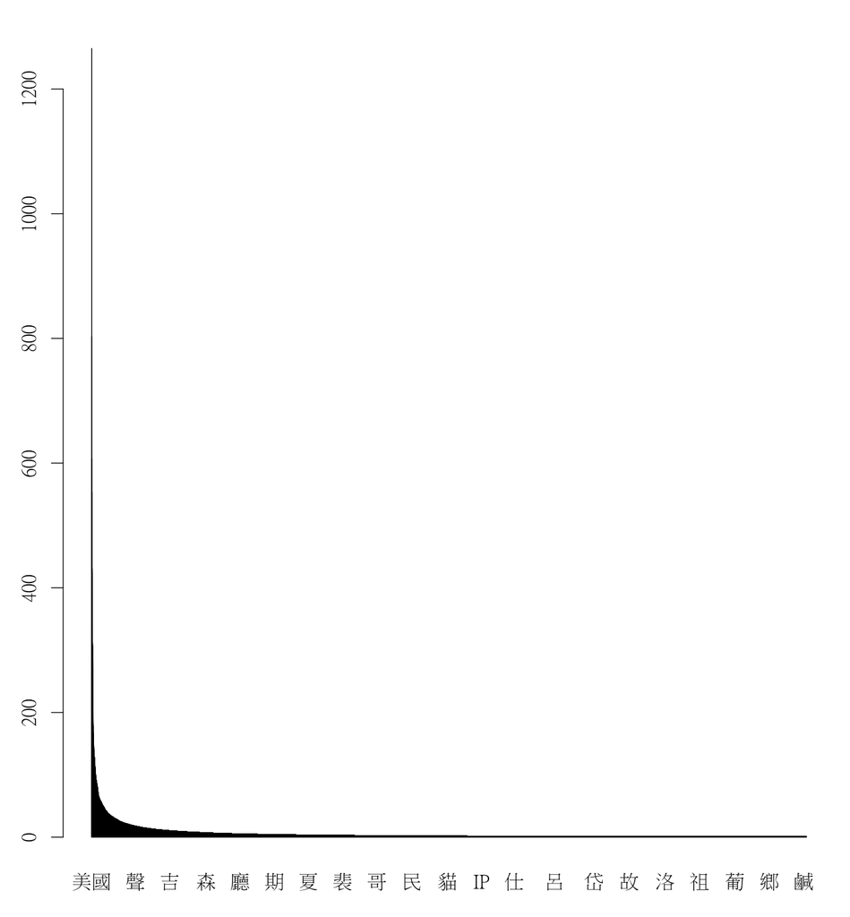

[figure not shown]

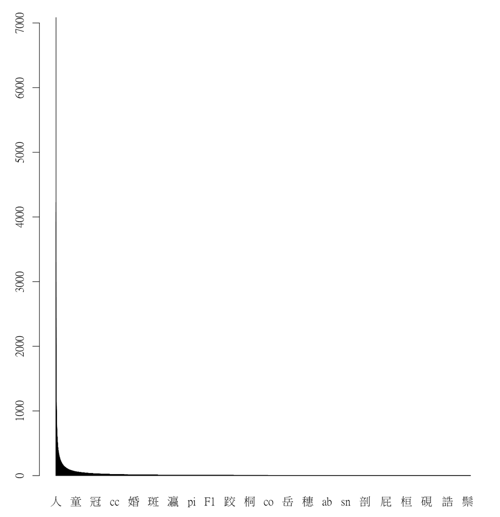

[figure not shown]

[figure not shown]

# Job Responsibilities

- **Task 1**: 李韶曼, 張凱雄
- **Taske 2**: 施中右, 周炫谷